# Bike Trips Analysis

Cody Thomas

2024-02-02

## Introduction

Cyclistic (not a real company) is interested in designing marketing strategies to better promote converting casual riders into annual members. Annual members are much more profitable compared to casual riders. The main goal of this analysis is to first determine how casual riders use Cyclystic bikes differently compared to the annual members.

In order to help answer this question, public data from Motivate International Inc. was used. Data sets in which the analysis was performed on was Q1 2019 and Q1 2020 bike trip data. These specific data sets were used rather than more recent or full year data sets due to the RAM restrictions of the Cloud Free Posit Cloud account. Adding more data sets or using larger data sets would routinely crash the session.

## Compiling the Data

Between 2019 and 2020, there were changes into the data fields that were tracked for the bike trips. The data wrangling involved 3 phases: * Make column names consistent between the 2 data sets * Combine the data sets into a single data frame * Remove columns that were not consistent between the 2 data sets

# Setting up the environment

```r
install.packages('tidyverse')
install.packages('lubridate')
```

```r
install.packages('ggplot2')
library(tidyverse)
library(lubridate)
library(ggplot2)
```

# Read in the data and make columns consistent between the data sets

```r
q1_2019 <- read.csv('Divvy_Trips_2019_Q1 - Divvy_Trips_2019_Q1.csv')
q1_2020 <- read.csv('Divvy_Trips_2020_Q1 - Divvy_Trips_2020_Q1.csv')
```

One these inconsistencies were dealt with, the final all_trips data frame was created by combining the rows of each data set.

```r
q1_2019 <- q1_2019 %>%
  rename(
    ride_id = trip_id,
    rideable_type = bikeid,
    started_at = start_time,
    ended_at = end_time,
    start_station_id = from_station_id,
    start_station_name = from_station_name,
    end_station_id = to_station_id,
    end_station_name = to_station_name,
    member_casual = usertype
  )

q1_2019 <- q1_2019 %>%
  mutate(ride_id = as.character(ride_id),
         rideable_type = as.character(rideable_type))

all_trips = bind_rows(q1_2019, q1_2020)
rm(q1_2019, q1_2020)

columns_to_remove = c("tripduration", "gender", "birthyear", "start_lat", "start_lng", "end_lat", "end_lng")
all_trips <- all_trips %>%
  select(-all_of(columns_to_remove))
```

# Cleaning the all_trips data frame

Once the 2019 and 2020 datasets were combined, the data cleaning process invovled dealing with the following inconsistencies.

- The naming of a casual rider or annual member differed between 2019 and 2020. In the 2019 data, annual members were referred to as ‘Subscribers’ and casual riders were labeled as ‘Customer’. In 2020, this changed to ‘member’ and ‘casual’.
- The starting date was expanded to add fields for year, month, day, and day of the week to allow for better grouping during the data analysis phase.
- A ride legth column was created to calculate the ride duration in minutes. This would mimic the removed ‘tripduration’ field from the Q1 2019 data set.
- ‘Bad’ data was removed. This included any bike trips that started at company HQ or trips that had a negative ride length.

The final working data frame for the data analysis was assigned to the all_trips_v2 variable.

```r
all_trips <- all_trips %>%
  mutate(member_casual = recode(member_casual,
                                "Subscriber" = "member",
                                "Customer" = "casual"))

all_trips <- all_trips %>%
  mutate(date = as_date(started_at),
         day = format(date, "%d"),
         month = format(date, "%m"),
         year = format(date, "%y"),
         day_of_week = format(date, "%A"),
         ride_length = as.numeric(difftime(ended_at, started_at, units="mins"))
  )

all_trips_v2 <- all_trips[(all_trips$start_station_name != "HQ QR" & all_trips$ride_length > 0),]
```

## Data Analysis

The data analysis was focused on the goal of determining how causal riders and annual members differed in how they use the Cyclistic bikes. The analysis looked into how ride length differs between the two groups and how the ride use changes as the week progresses.

First, ride duration summary statistics was calculated for both the whole data set and for the two rider types (annual members or casual riders).

```r
summary(all_trips_v2$ride_length)
```

```
##      Min.   1st Qu.    Median      Mean   3rd Qu.      Max.
##      0.02      5.52      8.98     19.82     15.20 177200.37
```

```r
aggregate(all_trips_v2$ride_length ~ all_trips_v2$member_casual, FUN=mean)
```

```
##   all_trips_v2$member_casual all_trips_v2$ride_length
## 1                     casual                 89.54640
## 2                     member                 13.25421
```

```r
aggregate(all_trips_v2$ride_length ~ all_trips_v2$member_casual, FUN=median)
```

```
##   all_trips_v2$member_casual all_trips_v2$ride_length
## 1                     casual                23.216667
## 2                     member                 8.466667
```

```r
aggregate(all_trips_v2$ride_length ~ all_trips_v2$member_casual, FUN=max)
```

```
##   all_trips_v2$member_casual all_trips_v2$ride_length
## 1                     casual                 177200.4
## 2                     member                 101607.1
```

```r
aggregate(all_trips_v2$ride_length ~ all_trips_v2$member_casual, FUN=min)
```

```
##   all_trips_v2$member_casual all_trips_v2$ride_length
## 1                     casual               0.03333333
## 2                     member               0.01666667
```

Annual members take shorter rides compared to the casual riders by a large margin. In addition, casual riders ride length sees large increases near the end of the standard working week (Thursday and Friday).

```r
all_trips_v2$day_of_week <- ordered(all_trips_v2$day_of_week,
                                    levels=c("Sunday", "Monday", "Tuesday", "Wednesday",
                                             "Thursday", "Friday", "Saturday")
                                    )

all_trips_v2 %>%
  group_by(member_casual, day_of_week) %>%
  summarize(mean(ride_length))
```

```
## # A tibble: 14 × 3
## # Groups:   member_casual [2]
##    member_casual day_of_week `mean(ride_length)`
##    <chr>         <ord>                     <dbl>
##  1 casual        Sunday                     84.4
##  2 casual        Monday                     79.2
##  3 casual        Tuesday                    76.0
##  4 casual        Wednesday                  74.7
##  5 casual        Thursday                  141.
##  6 casual        Friday                    102.
##  7 casual        Saturday                   82.5
##  8 member        Sunday                     16.2
##  9 member        Monday                     13.7
## 10 member        Tuesday                    12.8
## 11 member        Wednesday                  11.9
## 12 member        Thursday                   11.8
## 13 member        Friday                     13.3
## 14 member        Saturday                   16.2
```

This can also be visualized below.

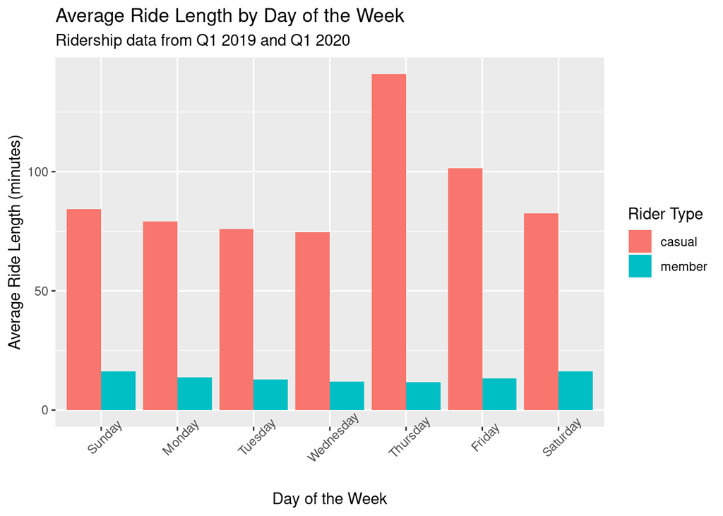

```r
all_trips_v2 %>%
  group_by(member_casual, day_of_week) %>%
  summarize(number_of_rides = n(),
            average_duration = mean(ride_length)) %>%
  ggplot(aes(x=day_of_week, y=average_duration, fill=member_casual)) +
  geom_col(position='dodge') +
  labs(title="Average Ride Length by Day of the Week", subtitle="Ridership data from Q1 2019 and Q1 2020",
       x="Day of the Week", y="Average Ride Length (minutes)", fill="Rider Type") +
  theme(axis.text.x = element_text(angle=45))
```

Next looking at the number of rides and how this changes by the week, we see another interesting trend. Annual members take more bike rides Monday - Friday, while casual riders see larger number of rides on weekend days.

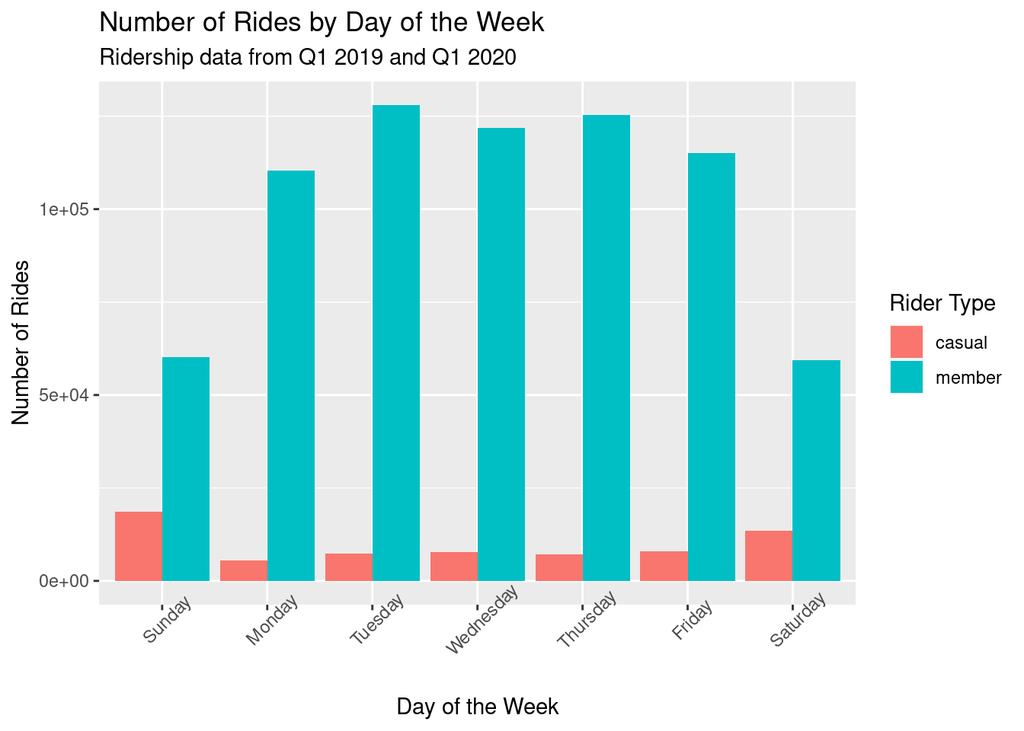

```r
all_trips_v2 %>%
  group_by(member_casual, day_of_week) %>%
  summarize(number_of_rides = n(),
            average_duration = mean(ride_length)) %>% # casual riders take more rides on the weekends, members take more rides during the weekdays
  # visualize
  ggplot(aes(x=day_of_week, y=number_of_rides, fill=member_casual)) +
  geom_col(position='dodge') +
  labs(title="Number of Rides by Day of the Week", subtitle="Ridership data from Q1 2019 and Q1 2020",
       x="Day of the Week", y="Number of Rides", fill="Rider Type") +
  theme(axis.text.x = element_text(angle=45))
```